# catchcompfigures

davidson

7/18/2023

# Length and catch composition differences between the DOG (fall) and HBLL inside north and south surveys.

```
## [1] 1986 1989 2005 2008 2011 2014 2019
```

```
## # A tibble: 11 × 2
##     year julian
##    <int>  <dbl>
##  1  2003    225
##  2  2004    238
##  3  2007    227
##  4  2008    228
##  5  2010    222
##  6  2012    220
##  7  2012    255
##  8  2014    217
##  9  2016    214
## 10  2019    207
## 11  2021    218
```

```
## # A tibble: 4 × 2
##    year     n
##   <int> <int>
## 1  1986     1
## 2  1989     5
## 3  2007     2
## 4  2018     1
```

```
##  [1] 1986 1989 2003 2004 2005 2007 2008 2009 2010 2011 2012 2013 2014 2015 2016
## [16] 2018 2019 2021 2022
```

```
## [1] 1 2
```

Variability of julian date across surveys.

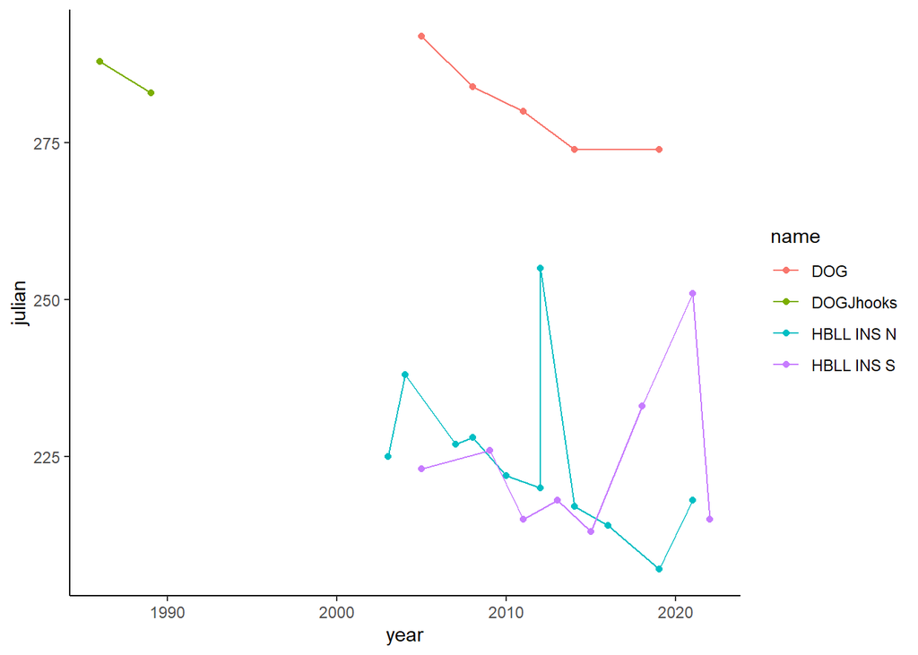

Density plots of sampled lengths across the four surveys.

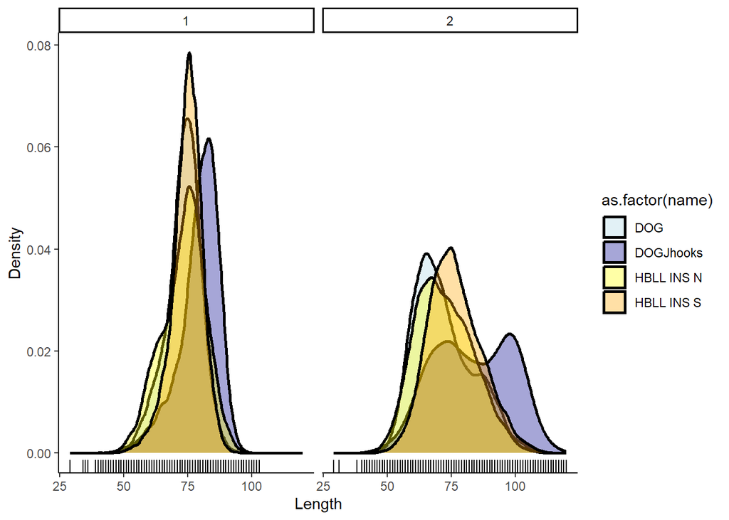

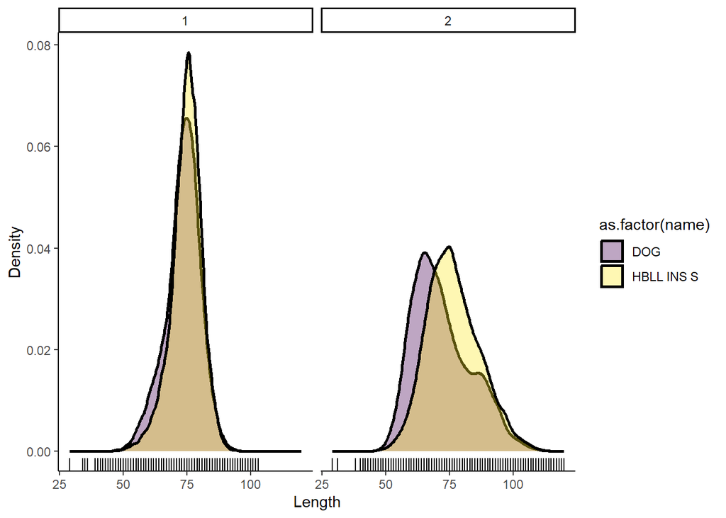

Variability of lengths across year by survey types and sex (1 = male, 2 = female).

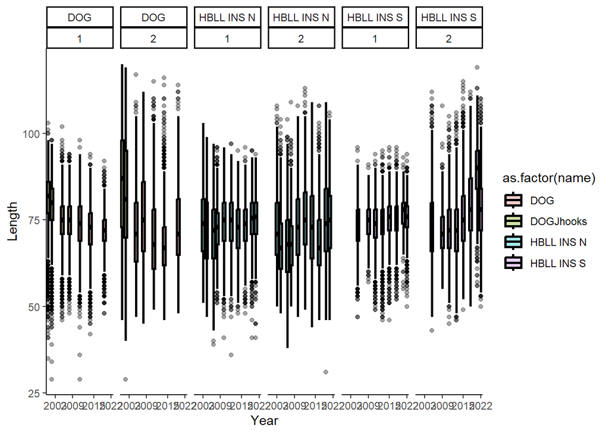

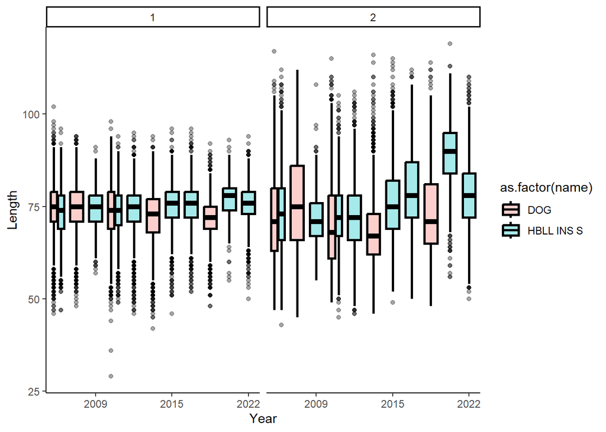

Tested for differences between group means using an anova.

```
## [1] 72.08474
```

```
## [1] 76.48274
```

```
##                Df  Sum Sq Mean Sq F value Pr(>F)
## name            3  552227  184076    1389 <2e-16 ***
## Residuals   45467 6024283     132
## ---
## Signif. codes:  0 '***' 0.001 '**' 0.01 '*' 0.05 '.' 0.1 ' ' 1
```

```
##   Tukey multiple comparisons of means
##     95% family-wise confidence level
##
## Fit: aov(formula = length ~ name, data = filter(samps, sex == 2))
##
## $name
##                              diff         lwr         upr     p adj
## DOGJhooks-DOG          11.1521692  10.6460048  11.6583336 0.0000000
## HBLL INS N-DOG          0.2612971  -0.1150789   0.6376731 0.2812212
## HBLL INS S-DOG          4.3979984   4.0381800   4.7578168 0.0000000
## HBLL INS N-DOGJhooks  -10.8908721 -11.3897838 -10.3919603 0.0000000
## HBLL INS S-DOGJhooks   -6.7541708  -7.2407129  -6.2676286 0.0000000
## HBLL INS S-HBLL INS N   4.1367013   3.7871591   4.4862435 0.0000000
```

```
##                Df  Sum Sq Mean Sq F value Pr(>F)
## name            3  355883  118628    2221 <2e-16 ***
## Residuals   70477 3764322      53
## ---
## Signif. codes:  0 '***' 0.001 '**' 0.01 '*' 0.05 '.' 0.1 ' ' 1
```

```
##   Tukey multiple comparisons of means
##     95% family-wise confidence level
##
## Fit: aov(formula = length ~ name, data = filter(samps, sex == 1))
##
## $name
##                               diff        lwr        upr     p adj
## DOGJhooks-DOG          5.966132307  5.7652105  6.1670541 0.0000000
## HBLL INS N-DOG         0.004125899 -0.1978614  0.2061132 0.9999482
## HBLL INS S-DOG         1.335582004  1.1542890  1.5168750 0.0000000
## HBLL INS N-DOGJhooks  -5.962006407 -6.1910420 -5.7329708 0.0000000
## HBLL INS S-DOGJhooks  -4.630550302 -4.8415611 -4.4195395 0.0000000
## HBLL INS S-HBLL INS N  1.331456105  1.1194305  1.5434817 0.0000000
```

Catch composition ratio.

[output not shown]

[output not shown]

[output cut: 30 more lines]

```
## # A tibble: 1 × 1
##       n
##   <int>
## 1  6984
```

```
## # A tibble: 1 × 1
##        n
##    <int>
## 1 115952
```

```
## [1] 108968
```

Each survey’s catches were divided based on length into maturity classes. Females are 95% mature at 95.5 cm, and males at 76.7 cm. Immatures were defined at those less than 77 and 65.1 cm for females and males respectively (i.e. 5% probability of being mature).

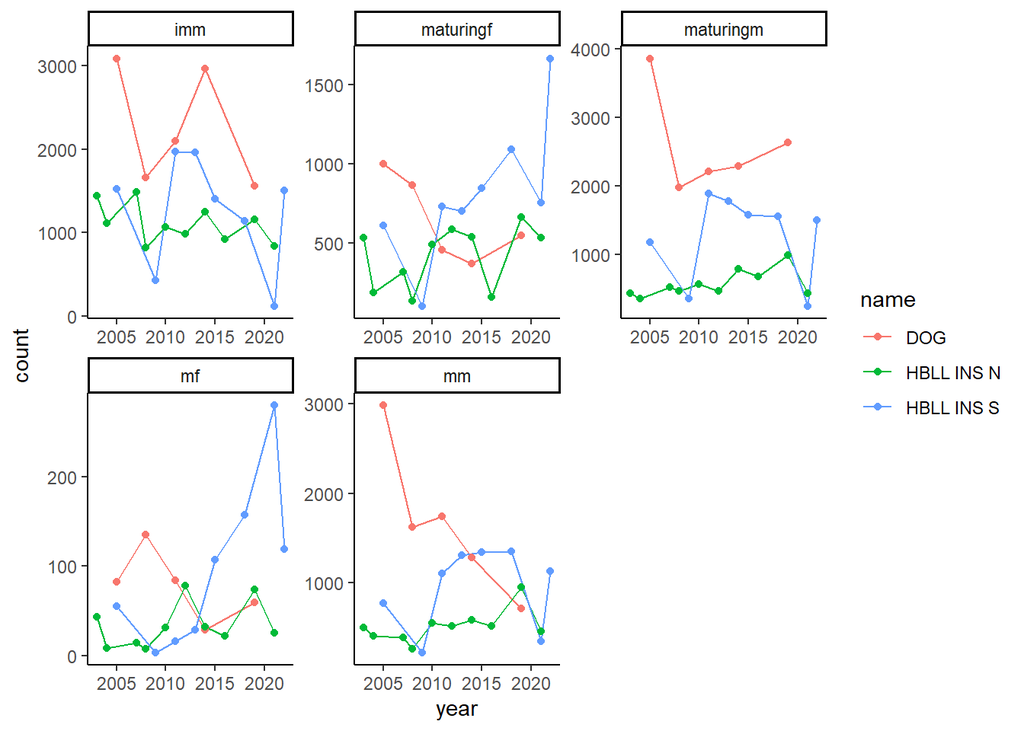

Mature female to mature male ratio.

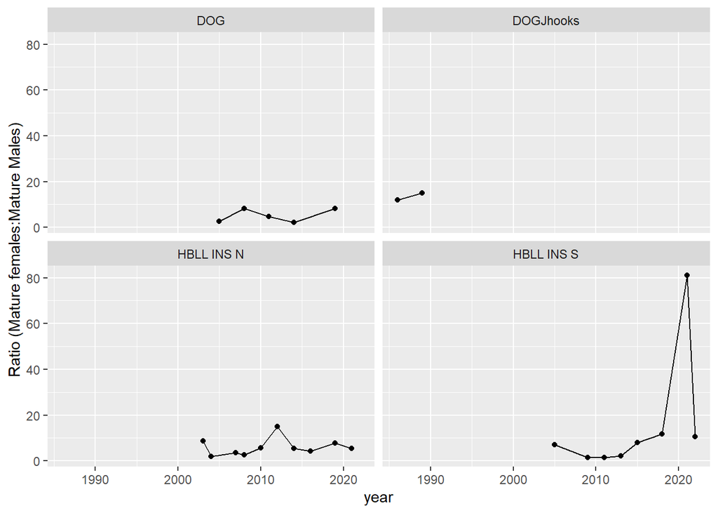

[output not shown]